← Probabilistic Machine Learning

# Schur Complement: Conditioning and Block Matrices

The **Schur complement** is what remains when we "remove" the influence of one part of a system from another. For a block matrix:

$$\mathbf{M} = \begin{pmatrix} \mathbf{A} & \mathbf{B} \\ \mathbf{C} & \mathbf{D} \end{pmatrix}$$

The **Schur complement of $\mathbf{D}$** is:

$$\mathbf{M}/\mathbf{D} = \mathbf{A} - \mathbf{B}\mathbf{D}^{-1}\mathbf{C}$$

### Why It Matters

- **Gaussian conditioning**: Conditional covariance = Schur complement
- **Block matrix inversion**: Key component of the formula
- **Information geometry**: "Information about A after observing D"
- **Sparse systems**: Enables efficient computation

```python
import numpy as np
import matplotlib.pyplot as plt
from matplotlib.patches import Ellipse

np.random.seed(42)
plt.rcParams['figure.figsize'] = (12, 6)
plt.rcParams['font.size'] = 11
```

## 1. The Fundamental Application: Gaussian Conditionals

For a joint Gaussian:

$$\begin{pmatrix} \mathbf{x}_1 \\ \mathbf{x}_2 \end{pmatrix} \sim N\left( \begin{pmatrix} \boldsymbol{\mu}_1 \\ \boldsymbol{\mu}_2 \end{pmatrix}, \begin{pmatrix} \mathbf{\Sigma}_{11} & \mathbf{\Sigma}_{12} \\ \mathbf{\Sigma}_{21} & \mathbf{\Sigma}_{22} \end{pmatrix} \right)$$

The conditional distribution $\mathbf{x}_1 | \mathbf{x}_2$ has:

$$\text{Cov}(\mathbf{x}_1 | \mathbf{x}_2) = \mathbf{\Sigma}_{11} - \mathbf{\Sigma}_{12} \mathbf{\Sigma}_{22}^{-1} \mathbf{\Sigma}_{21}$$

This is exactly the **Schur complement**!

```python
# Simple 2D example
# Joint distribution of (x1, x2) with correlation
rho = 0.8  # Correlation
Sigma = np.array([[1, rho],
                  [rho, 1]])

# Extract blocks (scalars in 2D case)
Sigma_11 = Sigma[0, 0]
Sigma_12 = Sigma[0, 1]
Sigma_21 = Sigma[1, 0]
Sigma_22 = Sigma[1, 1]

# Schur complement = conditional variance
Sigma_cond = Sigma_11 - Sigma_12 * (1/Sigma_22) * Sigma_21

print("Conditional Variance via Schur Complement")
print("="*50)
print(f"\nJoint covariance Σ:")
print(Sigma)
print(f"\nMarginal variance of x₁: Σ₁₁ = {Sigma_11}")
print(f"Correlation: ρ = {rho}")
print(f"\nSchur complement (conditional variance):")
print(f"  Σ₁₁ - Σ₁₂ Σ₂₂⁻¹ Σ₂₁ = {Sigma_11} - {Sigma_12}² / {Sigma_22}")
print(f"                       = {Sigma_11} - {Sigma_12**2}")
print(f"                       = {Sigma_cond}")
print(f"\nVariance reduction: {(1 - Sigma_cond/Sigma_11)*100:.1f}%")
```

```
Conditional Variance via Schur Complement
==================================================

Joint covariance Σ:
[[1.  0.8]
 [0.8 1. ]]

Marginal variance of x₁: Σ₁₁ = 1.0
Correlation: ρ = 0.8

Schur complement (conditional variance):
  Σ₁₁ - Σ₁₂ Σ₂₂⁻¹ Σ₂₁ = 1.0 - 0.8² / 1.0
                       = 1.0 - 0.6400000000000001
                       = 0.3599999999999999

Variance reduction: 64.0%
```

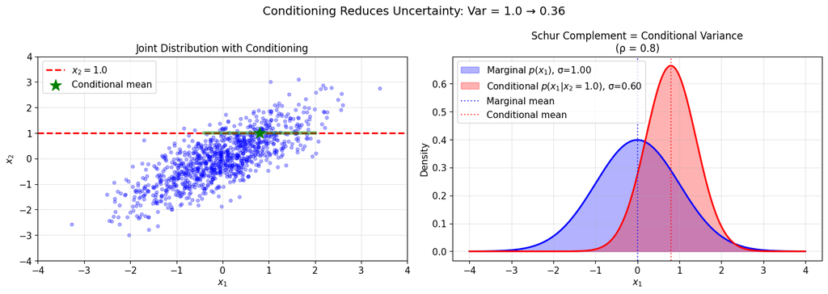

```python
# Visualize: Marginal vs Conditional
np.random.seed(42)
n_samples = 1000
samples = np.random.multivariate_normal([0, 0], Sigma, n_samples)

# Condition on x2 = 1
x2_observed = 1.0
x1_conditional_mean = Sigma_12 / Sigma_22 * x2_observed
x1_conditional_std = np.sqrt(Sigma_cond)

fig, axes = plt.subplots(1, 2, figsize=(14, 5))

# Left: Joint distribution with conditioning line
ax1 = axes[0]
ax1.scatter(samples[:, 0], samples[:, 1], alpha=0.3, s=15, c='blue')
ax1.axhline(y=x2_observed, color='red', linestyle='--', linewidth=2, label=f'$x_2 = {x2_observed}$')
ax1.scatter([x1_conditional_mean], [x2_observed], c='green', s=200, marker='*',
            zorder=5, label=f'Conditional mean')

# Show conditional uncertainty as horizontal bar
ax1.plot([x1_conditional_mean - 2*x1_conditional_std, x1_conditional_mean + 2*x1_conditional_std],
         [x2_observed, x2_observed], 'g-', linewidth=4, alpha=0.5)

ax1.set_xlabel('$x_1$')
ax1.set_ylabel('$x_2$')
ax1.set_title('Joint Distribution with Conditioning', fontsize=12)
ax1.legend(loc='upper left')
ax1.grid(True, alpha=0.3)
ax1.set_xlim(-4, 4)
ax1.set_ylim(-4, 4)

# Right: Marginal vs Conditional of x1
ax2 = axes[1]
x_range = np.linspace(-4, 4, 200)

# Marginal distribution of x1
marginal_pdf = 1/np.sqrt(2*np.pi*Sigma_11) * np.exp(-x_range**2 / (2*Sigma_11))
ax2.fill_between(x_range, marginal_pdf, alpha=0.3, color='blue', label=f'Marginal $p(x_1)$, σ={np.sqrt(Sigma_11):.2f}')
ax2.plot(x_range, marginal_pdf, 'b-', linewidth=2)

# Conditional distribution of x1 | x2
conditional_pdf = 1/np.sqrt(2*np.pi*Sigma_cond) * np.exp(-(x_range - x1_conditional_mean)**2 / (2*Sigma_cond))
ax2.fill_between(x_range, conditional_pdf, alpha=0.3, color='red',
                 label=f'Conditional $p(x_1 | x_2={x2_observed})$, σ={x1_conditional_std:.2f}')
ax2.plot(x_range, conditional_pdf, 'r-', linewidth=2)

ax2.axvline(x=0, color='blue', linestyle=':', alpha=0.7, label='Marginal mean')
ax2.axvline(x=x1_conditional_mean, color='red', linestyle=':', alpha=0.7, label=f'Conditional mean')

ax2.set_xlabel('$x_1$')
ax2.set_ylabel('Density')
ax2.set_title(f'Schur Complement = Conditional Variance\n(ρ = {rho})', fontsize=12)
ax2.legend()
ax2.grid(True, alpha=0.3)

plt.suptitle(f'Conditioning Reduces Uncertainty: Var = {Sigma_11} → {Sigma_cond:.2f}', fontsize=14)
plt.tight_layout()
plt.show()
```

## Real-World Scenario: Medical Diagnosis

**Scenario**: A doctor is estimating a patient's blood pressure. They have:

- Prior uncertainty about blood pressure (from population statistics)
- A correlated measurement: heart rate

Knowing the patient's heart rate **reduces uncertainty** about blood pressure. The Schur complement tells us by how much!

```python
# Medical example: Blood pressure and heart rate
# Joint distribution based on population statistics

# Means
mu_bp = 120    # Systolic BP in mmHg
mu_hr = 72     # Heart rate in BPM

# Standard deviations
sigma_bp = 15  # BP varies quite a bit
sigma_hr = 10  # Heart rate too

# Correlation (BP and HR are positively correlated)
rho = 0.6

# Build covariance matrix
Sigma = np.array([
    [sigma_bp**2, rho*sigma_bp*sigma_hr],
    [rho*sigma_bp*sigma_hr, sigma_hr**2]
])

print("Medical Diagnosis: Estimating Blood Pressure")
print("="*50)
print(f"\nPopulation statistics (prior):")
print(f"  Blood pressure: {mu_bp} ± {sigma_bp} mmHg")
print(f"  Heart rate: {mu_hr} ± {sigma_hr} BPM")
print(f"  Correlation: ρ = {rho}")
print(f"\nCovariance matrix:")
print(Sigma)
```

```
Medical Diagnosis: Estimating Blood Pressure
==================================================

Population statistics (prior):
  Blood pressure: 120 ± 15 mmHg
  Heart rate: 72 ± 10 BPM
  Correlation: ρ = 0.6

Covariance matrix:
[[225.  90.]
 [ 90. 100.]]
```

```python
# Patient comes in with heart rate = 85 BPM (elevated)
observed_hr = 85

# Conditional distribution using Schur complement
Sigma_11 = Sigma[0, 0]  # Var(BP)
Sigma_12 = Sigma[0, 1]  # Cov(BP, HR)
Sigma_22 = Sigma[1, 1]  # Var(HR)

# Conditional mean: E[BP | HR]
conditional_mean_bp = mu_bp + Sigma_12 / Sigma_22 * (observed_hr - mu_hr)

# Conditional variance: Schur complement
conditional_var_bp = Sigma_11 - Sigma_12**2 / Sigma_22
conditional_std_bp = np.sqrt(conditional_var_bp)

print(f"\nPatient observation: Heart rate = {observed_hr} BPM")
print(f"\nUsing Schur complement for conditional distribution:")
print(f"\n  E[BP | HR={observed_hr}] = μ_BP + (Σ_12/Σ_22)(HR - μ_HR)")
print(f"                         = {mu_bp} + ({Sigma_12}/{Sigma_22})({observed_hr} - {mu_hr})")
print(f"                         = {mu_bp} + {Sigma_12/Sigma_22:.2f} × {observed_hr - mu_hr}")
print(f"                         = {conditional_mean_bp:.1f} mmHg")
print(f"\n  Var[BP | HR] = Σ_11 - Σ_12²/Σ_22  (Schur complement)")
print(f"              = {Sigma_11} - {Sigma_12**2}/{Sigma_22}")
print(f"              = {conditional_var_bp:.1f}")
print(f"  Std[BP | HR] = {conditional_std_bp:.1f} mmHg")

print(f"\nSummary:")
print(f"  Prior (no HR info):     BP = {mu_bp} ± {sigma_bp} mmHg")
print(f"  Posterior (HR known):   BP = {conditional_mean_bp:.1f} ± {conditional_std_bp:.1f} mmHg")
print(f"\n  Uncertainty reduced by {(1 - conditional_std_bp/sigma_bp)*100:.1f}%")
```

```
Patient observation: Heart rate = 85 BPM

Using Schur complement for conditional distribution:

  E[BP | HR=85] = μ_BP + (Σ_12/Σ_22)(HR - μ_HR)
                         = 120 + (90.0/100.0)(85 - 72)
                         = 120 + 0.90 × 13
                         = 131.7 mmHg

  Var[BP | HR] = Σ_11 - Σ_12²/Σ_22  (Schur complement)
              = 225.0 - 8100.0/100.0
              = 144.0
  Std[BP | HR] = 12.0 mmHg

Summary:
  Prior (no HR info):     BP = 120 ± 15 mmHg
  Posterior (HR known):   BP = 131.7 ± 12.0 mmHg

  Uncertainty reduced by 20.0%
```

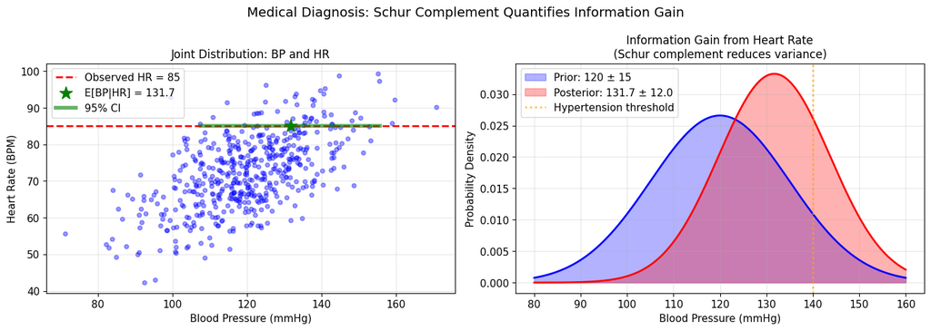

```python
# Visualize
fig, axes = plt.subplots(1, 2, figsize=(14, 5))

# Generate samples from joint
np.random.seed(42)
samples = np.random.multivariate_normal([mu_bp, mu_hr], Sigma, 500)

# Left: Joint distribution
ax1 = axes[0]
ax1.scatter(samples[:, 0], samples[:, 1], alpha=0.4, s=20, c='blue')
ax1.axhline(y=observed_hr, color='red', linestyle='--', linewidth=2,
            label=f'Observed HR = {observed_hr}')
ax1.scatter([conditional_mean_bp], [observed_hr], c='green', s=200, marker='*',
            zorder=5, label=f'E[BP|HR] = {conditional_mean_bp:.1f}')

# Show 2σ interval
ax1.plot([conditional_mean_bp - 2*conditional_std_bp, conditional_mean_bp + 2*conditional_std_bp],
         [observed_hr, observed_hr], 'g-', linewidth=4, alpha=0.6, label='95% CI')

ax1.set_xlabel('Blood Pressure (mmHg)')
ax1.set_ylabel('Heart Rate (BPM)')
ax1.set_title('Joint Distribution: BP and HR', fontsize=12)
ax1.legend(loc='upper left')
ax1.grid(True, alpha=0.3)

# Right: Prior vs Posterior for BP
ax2 = axes[1]
bp_range = np.linspace(80, 160, 200)

# Prior
prior_pdf = 1/np.sqrt(2*np.pi*sigma_bp**2) * np.exp(-(bp_range - mu_bp)**2 / (2*sigma_bp**2))
ax2.fill_between(bp_range, prior_pdf, alpha=0.3, color='blue', label=f'Prior: {mu_bp} ± {sigma_bp}')
ax2.plot(bp_range, prior_pdf, 'b-', linewidth=2)

# Posterior
posterior_pdf = 1/np.sqrt(2*np.pi*conditional_var_bp) * np.exp(-(bp_range - conditional_mean_bp)**2 / (2*conditional_var_bp))
ax2.fill_between(bp_range, posterior_pdf, alpha=0.3, color='red',
                 label=f'Posterior: {conditional_mean_bp:.1f} ± {conditional_std_bp:.1f}')
ax2.plot(bp_range, posterior_pdf, 'r-', linewidth=2)

ax2.axvline(x=140, color='orange', linestyle=':', linewidth=2, alpha=0.7, label='Hypertension threshold')
ax2.set_xlabel('Blood Pressure (mmHg)')
ax2.set_ylabel('Probability Density')
ax2.set_title(f'Information Gain from Heart Rate\n(Schur complement reduces variance)', fontsize=12)
ax2.legend()
ax2.grid(True, alpha=0.3)

plt.suptitle('Medical Diagnosis: Schur Complement Quantifies Information Gain', fontsize=14)
plt.tight_layout()
plt.show()
```

## 2. The Formula: Block Matrix Inversion

The Schur complement is key to inverting block matrices:

$$\begin{pmatrix} \mathbf{A} & \mathbf{B} \\ \mathbf{C} & \mathbf{D} \end{pmatrix}^{-1} = \begin{pmatrix} (\mathbf{A} - \mathbf{B}\mathbf{D}^{-1}\mathbf{C})^{-1} & \cdots \\ \cdots & \cdots \end{pmatrix}$$

The top-left block of the inverse is the **inverse of the Schur complement**!

```python
# Demonstrate block matrix inversion
A = np.array([[4, 1], [1, 3]])
B = np.array([[1, 0], [0, 1]])
C = np.array([[1, 0], [0, 1]])  # C = B for symmetric case
D = np.array([[2, 0.5], [0.5, 2]])

# Build full matrix
M = np.block([[A, B], [C, D]])

# Direct inversion
M_inv = np.linalg.inv(M)

# Schur complement of D
D_inv = np.linalg.inv(D)
schur_D = A - B @ D_inv @ C
schur_D_inv = np.linalg.inv(schur_D)

print("Block Matrix Inversion via Schur Complement")
print("="*50)
print(f"\nMatrix M (4×4):")
print(M)
print(f"\nDirect inverse M⁻¹ (top-left 2×2 block):")
print(M_inv[:2, :2].round(4))
print(f"\nSchur complement of D: A - B D⁻¹ C =")
print(schur_D.round(4))
print(f"\nInverse of Schur complement:")
print(schur_D_inv.round(4))
print(f"\nThey match: {np.allclose(M_inv[:2, :2], schur_D_inv)}")
```

```
Block Matrix Inversion via Schur Complement
==================================================

Matrix M (4×4):
[[4.  1.  1.  0. ]
 [1.  3.  0.  1. ]
 [1.  0.  2.  0.5]
 [0.  1.  0.5 2. ]]

Direct inverse M⁻¹ (top-left 2×2 block):
[[ 0.3394 -0.156 ]
 [-0.156   0.4771]]

Schur complement of D: A - B D⁻¹ C =
[[3.4667 1.1333]
 [1.1333 2.4667]]

Inverse of Schur complement:
[[ 0.3394 -0.156 ]
 [-0.156   0.4771]]

They match: True
```

## 3. Higher Dimensions: Multiple Conditioning Variables

The Schur complement works for any partitioning of variables.

```python
# 4D example: Conditioning on 2 variables
# Variables: [weight, height, age, cholesterol]
# We'll condition cholesterol on [weight, height, age]

# Realistic covariance matrix (approximate)
Sigma_full = np.array([
    [400, 50, 5, 80],      # weight (lbs)
    [50, 16, 0.5, 10],     # height (inches)
    [5, 0.5, 100, 20],     # age (years)
    [80, 10, 20, 900]      # cholesterol (mg/dL)
])

# Partition: x1 = [cholesterol], x2 = [weight, height, age]
Sigma_11 = Sigma_full[3:4, 3:4]   # (1,1) - cholesterol variance
Sigma_12 = Sigma_full[3:4, 0:3]   # (1,3) - cholesterol-others covariance
Sigma_21 = Sigma_full[0:3, 3:4]   # (3,1)
Sigma_22 = Sigma_full[0:3, 0:3]   # (3,3) - others covariance

# Schur complement: conditional variance of cholesterol given all others
Sigma_22_inv = np.linalg.inv(Sigma_22)
Sigma_cond = Sigma_11 - Sigma_12 @ Sigma_22_inv @ Sigma_21

print("Multivariate Conditioning Example")
print("="*50)
print(f"\nVariables: weight, height, age, cholesterol")
print(f"\nMarginal std(cholesterol) = {np.sqrt(Sigma_11[0,0]):.1f} mg/dL")
print(f"\nConditional std(cholesterol | weight, height, age)")
print(f"  = √(Schur complement)")
print(f"  = {np.sqrt(Sigma_cond[0,0]):.1f} mg/dL")
print(f"\nKnowing weight, height, and age reduces cholesterol uncertainty by")
print(f"  {(1 - np.sqrt(Sigma_cond[0,0])/np.sqrt(Sigma_11[0,0]))*100:.1f}%")
```

```
Multivariate Conditioning Example
==================================================

Variables: weight, height, age, cholesterol

Marginal std(cholesterol) = 30.0 mg/dL

Conditional std(cholesterol | weight, height, age)
  = √(Schur complement)
  = 29.7 mg/dL

Knowing weight, height, and age reduces cholesterol uncertainty by
  1.1%
```

## 4. Intuition: Information Decomposition

The Schur complement has a beautiful interpretation:

$$\text{Var}(x_1) = \underbrace{\text{Var}(x_1 | x_2)}_{\text{Schur complement}} + \underbrace{\text{"Variance explained by } x_2\text{"}}_{\Sigma_{12} \Sigma_{22}^{-1} \Sigma_{21}}$$

The second term is the **reduction in variance** due to knowing $x_2$.

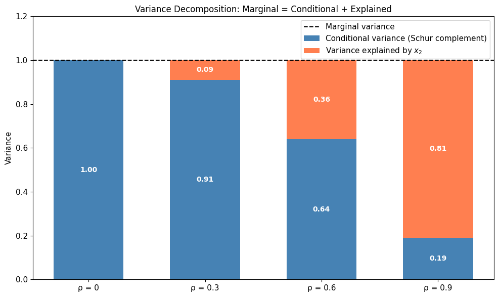

```
As correlation increases, more variance is 'explained' by conditioning,
and the Schur complement (residual uncertainty) decreases.
```

```python
# Variance decomposition
rho_values = [0, 0.3, 0.6, 0.9]

fig, ax = plt.subplots(figsize=(10, 6))

# Original variance
original_var = 1.0

x = np.arange(len(rho_values))
width = 0.6

conditional_vars = [original_var - rho**2 for rho in rho_values]
explained_vars = [rho**2 for rho in rho_values]

# Stacked bar chart
bars1 = ax.bar(x, conditional_vars, width, label='Conditional variance (Schur complement)', color='steelblue')
bars2 = ax.bar(x, explained_vars, width, bottom=conditional_vars,
               label='Variance explained by $x_2$', color='coral')

ax.set_xticks(x)
ax.set_xticklabels([f'ρ = {rho}' for rho in rho_values])
ax.set_ylabel('Variance')
ax.set_title('Variance Decomposition: Marginal = Conditional + Explained', fontsize=12)
ax.axhline(y=original_var, color='black', linestyle='--', linewidth=1.5, label='Marginal variance')
ax.legend()
ax.set_ylim(0, 1.2)

# Annotate
for i, (cond, expl, rho) in enumerate(zip(conditional_vars, explained_vars, rho_values)):
    ax.text(i, cond/2, f'{cond:.2f}', ha='center', va='center', fontsize=10, color='white', fontweight='bold')
    if expl > 0.05:
        ax.text(i, cond + expl/2, f'{expl:.2f}', ha='center', va='center', fontsize=10, color='white', fontweight='bold')

plt.tight_layout()
plt.show()

print("\nAs correlation increases, more variance is 'explained' by conditioning,")
print("and the Schur complement (residual uncertainty) decreases.")
```

## 5. Key Property: Conditional Covariance is Constant

A remarkable property of the Gaussian distribution: **the conditional covariance does not depend on the observed value**.

$$\text{Cov}(x_1 | x_2 = a) = \Sigma_{11} - \Sigma_{12}\Sigma_{22}^{-1}\Sigma_{21}$$

Notice: the right side contains only covariance matrix blocks — no $a$ appears!

| Quantity | Formula | Depends on observed value? |
| --- | --- | --- |
| Conditional **mean** | $\mu_1 + \Sigma_{12}\Sigma_{22}^{-1}(a - \mu_2)$ | ✅ Yes |
| Conditional **covariance** | $\Sigma_{11} - \Sigma_{12}\Sigma_{22}^{-1}\Sigma_{21}$ | ❌ No |

**Implications:**

- We can compute uncertainty reduction *before* observing anything
- Useful for experimental design: "How much will measuring X reduce uncertainty about Y?"
- Enables efficient algorithms (e.g., Kalman filter precomputes covariance updates)
- This is a **unique property of Gaussians** — non-Gaussian conditionals can have value-dependent variance

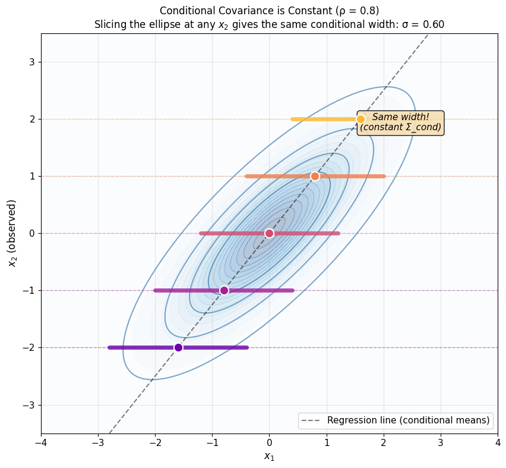

```
Conditional variance Var(x₁|x₂) = 0.3600  (same for ALL observed values)
Conditional std σ(x₁|x₂) = 0.6000

This can be computed BEFORE observing any data!
```

```python
# Demonstrate: Conditional covariance is CONSTANT across different observed values
rho = 0.8
Sigma = np.array([[1, rho], [rho, 1]])

# Schur complement (conditional variance) - computed ONCE
Sigma_cond = Sigma[0,0] - Sigma[0,1]**2 / Sigma[1,1]

# Different observed values of x2
x2_values = [-2, -1, 0, 1, 2]

fig, ax = plt.subplots(figsize=(10, 8))

# Create grid for contour plot
x1_grid = np.linspace(-4, 4, 200)
x2_grid = np.linspace(-3.5, 3.5, 200)
X1, X2 = np.meshgrid(x1_grid, x2_grid)
pos = np.dstack((X1, X2))

# Compute joint PDF
from scipy.stats import multivariate_normal
rv = multivariate_normal([0, 0], Sigma)
Z = rv.pdf(pos)

# Plot contours of joint distribution
contour_levels = [0.01, 0.05, 0.1, 0.15]
contours = ax.contour(X1, X2, Z, levels=contour_levels, colors='steelblue', alpha=0.7, linewidths=1.5)
ax.contourf(X1, X2, Z, levels=20, cmap='Blues', alpha=0.3)

# Plot conditional distributions for each observed x2
colors = plt.cm.plasma(np.linspace(0.2, 0.85, len(x2_values)))

for x2_obs, color in zip(x2_values, colors):
    # Conditional mean CHANGES with observed value
    cond_mean = Sigma[0,1] / Sigma[1,1] * x2_obs
    # Conditional std is CONSTANT (Schur complement)
    cond_std = np.sqrt(Sigma_cond)

    # Draw horizontal line at x2_obs
    ax.axhline(y=x2_obs, color=color, linestyle='--', alpha=0.4, linewidth=1)

    # Mark conditional mean and ±2σ interval
    ax.scatter([cond_mean], [x2_obs], c=[color], s=120, marker='o', zorder=5,
               edgecolor='white', linewidth=1.5)
    ax.plot([cond_mean - 2*cond_std, cond_mean + 2*cond_std], [x2_obs, x2_obs],
            color=color, linewidth=5, alpha=0.8, solid_capstyle='round')

# Add annotation
ax.annotate('Same width!\n(constant Σ_cond)', xy=(2.3, 1.8), fontsize=11,
            ha='center', style='italic',
            bbox=dict(boxstyle='round', facecolor='wheat', alpha=0.9))

# Draw regression line (line of conditional means)
x2_line = np.linspace(-3.5, 3.5, 100)
x1_line = Sigma[0,1] / Sigma[1,1] * x2_line
ax.plot(x1_line, x2_line, 'k--', linewidth=1.5, alpha=0.5, label='Regression line (conditional means)')

ax.set_xlabel('$x_1$', fontsize=12)
ax.set_ylabel('$x_2$ (observed)', fontsize=12)
ax.set_title(f'Conditional Covariance is Constant (ρ = {rho})\n'
             f'Slicing the ellipse at any $x_2$ gives the same conditional width: σ = {np.sqrt(Sigma_cond):.2f}',
             fontsize=12)
ax.set_xlim(-4, 4)
ax.set_ylim(-3.5, 3.5)
ax.set_aspect('equal')
ax.legend(loc='lower right')
ax.grid(True, alpha=0.3)

plt.tight_layout()
plt.show()

print(f"Conditional variance Var(x₁|x₂) = {Sigma_cond:.4f}  (same for ALL observed values)")
print(f"Conditional std σ(x₁|x₂) = {np.sqrt(Sigma_cond):.4f}")
print(f"\nThis can be computed BEFORE observing any data!")
```

## 6. Connection to Precision Matrix

There's a duality between the Schur complement of the covariance and the precision matrix:

- $(\Sigma^{-1})_{11}$ = Inverse of Schur complement of $\Sigma_{22}$
- **Conditional precision** has a simpler form in the precision parameterization

```python
# Precision matrix and Schur complement relationship
Sigma = np.array([[1, 0.7], [0.7, 1]])
Lambda = np.linalg.inv(Sigma)  # Precision matrix

# Schur complement of Sigma
schur_sigma = Sigma[0,0] - Sigma[0,1]**2 / Sigma[1,1]

print("Covariance-Precision Duality")
print("="*50)
print(f"\nCovariance Σ:")
print(Sigma)
print(f"\nPrecision Λ = Σ⁻¹:")
print(Lambda.round(4))
print(f"\nSchur complement of Σ (conditional variance):")
print(f"  Σ₁₁ - Σ₁₂²/Σ₂₂ = {schur_sigma:.4f}")
print(f"\nλ₁₁ (precision matrix diagonal):")
print(f"  Λ₁₁ = {Lambda[0,0]:.4f}")
print(f"\nRelationship: Λ₁₁ = 1/(Schur complement) = {1/schur_sigma:.4f}")
print(f"Match: {np.isclose(Lambda[0,0], 1/schur_sigma)}")
```

```
Covariance-Precision Duality
==================================================

Covariance Σ:
[[1.  0.7]
 [0.7 1. ]]

Precision Λ = Σ⁻¹:
[[ 1.9608 -1.3725]
 [-1.3725  1.9608]]

Schur complement of Σ (conditional variance):
  Σ₁₁ - Σ₁₂²/Σ₂₂ = 0.5100

λ₁₁ (precision matrix diagonal):
  Λ₁₁ = 1.9608

Relationship: Λ₁₁ = 1/(Schur complement) = 1.9608
Match: True
```

## Key Takeaways

1. **Schur complement**: $\mathbf{A} - \mathbf{B}\mathbf{D}^{-1}\mathbf{C}$
   - "What remains of A after removing D's influence"
2. **Gaussian conditioning**: Conditional variance = Schur complement $$\text{Var}(x_1 | x_2) = \Sigma_{11} - \Sigma_{12}\Sigma_{22}^{-1}\Sigma_{21}$$
3. **Conditional covariance is constant** (unique to Gaussians!):
   - Does NOT depend on the observed value, only on the covariance structure
   - Can be computed *before* any observation is made
   - The conditional mean shifts; the conditional covariance stays fixed
4. **Variance decomposition**: $$\text{Marginal var} = \text{Conditional var} + \text{Explained var}$$
5. **Block matrix inversion**: Schur complement appears in the inverse formula
6. **Applications**:
   - Bayesian inference (updating beliefs)
   - Medical diagnosis (combining evidence)
   - Kalman filtering (measurement updates)
   - Experimental design (predict uncertainty reduction before measuring)

**This completes our journey through matrix-vector multiplication patterns!**

From basic products to the sophisticated Schur complement, these operations form the foundation of probabilistic machine learning.